# DGP Dossier: synth_baseline

## 1. Identity & Status

| DGP ID | synth_baseline |
| --- | --- |
| Version | 1.6.0 |
| Status | stable |
| Difficulty | ★☆☆☆☆ (1/5) |
| Stress Profile | overlap: moderatenoise: gaussianlinearity: lineareffect: lineartarget: both |

## 2. What This DGP Stresses (Intent)

Baseline sanity check: if an estimator fails here, it is fundamentally broken. Intended to confirm correct implementation under ideal linear, well-behaved conditions.

## 3. Identification Assumptions (Explicit)

- Selection on observables holds.
- Overlap is moderate (propensity bounded).
- SUTVA holds.

## 4. Mathematical Specification

Covariates: $X_1, X_2, X_3, X_4, X_5 \sim \mathcal{N}(0, 1^2)$ independently. Only $X_1, X_2$ drive outcomes and treatment.

**Outcome (control):**
$$\mu_0(X) = 1 + X_1 + 0.5 X_2$$

**Propensity:**
$$p(X) =
\text{expit}(0.5 X_1 - 0.5 X_2)$$

**Treatment effect:**
$$\tau(X) = 1 + 0.5 X_1$$

**Potential Outcomes:**
$$Y_0
= \mu_0(X) + \varepsilon_0$$
$$Y_1 =
\mu_0(X) + \tau(X) + \varepsilon_1$$
where $\varepsilon_0, \varepsilon_1 \sim \mathcal{N}(0, 0.5^2)$ are independent.

## 5. Oracle Truth Definition

- True ATT is calculated as the sample mean of `structural_te` among treated units.
- No Monte Carlo approximation needed for ATT (exact sample truth).

## 6. Visual Diagnostics (n = 5000)

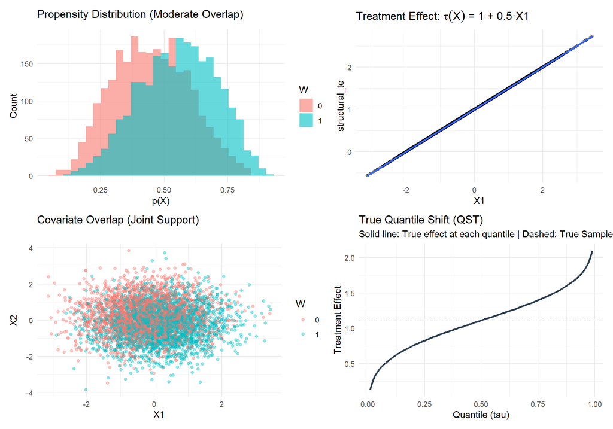

## 7. Empirical Validation

We expect correctly specified OLS (`lm_att`) and the oracle to be essentially unbiased on this baseline.

Empirical validation (n=5000, seeds=1:10)

| estimator_id | mean_bias | rmse |
| --- | --- | --- |
| lm_att | 0.002 | 0.012 |
| oracle_att | 0.000 | 0.000 |

## 8. Failure Mode Summary

- Naive estimators (unadjusted) fail due to confounding.
- L2 estimators succeed (linear surface).
- Propensity estimators succeed (moderate overlap).

## 9. Implementation Reference

- Code: `R/dgp-synth-baseline.R` (v1.6.0)
- Registry: `cs_dgp_registry()` entry for `synth_baseline`
- Oracle: `true_att` computed from `structural_te` among treated
- Oracle truth: `cs_get_oracle_qst("synth_baseline", version = "1.6.0")`
- Airlock: oracle columns removed unless explicitly allowed

## 10. Validation Checklist

- Math matches code
- Oracle matches definition
- Visual diagnostics show intended properties
- Empirical validation (lm_att vs oracle_att) passes
- Stress profile/difficulty tags set

## 11. Changelog

- v1.0 dossier: Initial dossier following Standard Template v1.0
- v1.6.0: Implemented Common Random Numbers (CRN) for Oracle generation. Eliminates Monte Carlo noise in QST truth benchmarks.

## Appendix: Implementation

```
Source code for: dgp_synth_baseline_v160

function(n, seed = NULL, include_truth = TRUE, oracle_only = FALSE) {
  if (!is.null(seed)) {
    cs_set_rng(seed)
  }

  X1 <- stats::rnorm(n, mean = 0, sd = 1)
  X2 <- stats::rnorm(n, mean = 0, sd = 1)
  if (!isTRUE(oracle_only)) {
    X3 <- stats::rnorm(n, mean = 0, sd = 1)
    X4 <- stats::rnorm(n, mean = 0, sd = 1)
    X5 <- stats::rnorm(n, mean = 0, sd = 1)
  }

  mu0 <- 1 + X1 + 0.5 * X2
  tau <- 1 + 0.5 * X1
  p <- stats::plogis(0.5 * X1 - 0.5 * X2)

  w <- stats::rbinom(n, size = 1, prob = p)

  eps0 <- stats::rnorm(n, mean = 0, sd = 0.5)

  if (isTRUE(oracle_only)) {
    eps1 <- eps0
  } else {
    eps1 <- stats::rnorm(n, mean = 0, sd = 0.5)
  }

  y0 <- mu0 + eps0
  y1 <- mu0 + tau + eps1

  if (isTRUE(oracle_only)) {
    return(list(df = tibble::tibble(w = w, y0 = y0, y1 = y1)))
  }

  y <- ifelse(w == 1, y1, y0)

  true_att <- cs_true_att(structural_te = tau, w = w)
  true_qst <- if (isTRUE(include_truth)) cs_get_oracle_qst("synth_baseline", version = "1.6.0") else NULL
```

[output cut: 13 more lines]

```
      X5 = X5
    ),
    true_att = true_att,
    true_qst = true_qst,
    meta = list(
      dgp_id = "synth_baseline",
      version = "1.6.0",
      type = "synthetic",
      params = list(n = n, seed = seed),
      structural_te = tau
    )
  )
}
<bytecode: 0x000001d54208f770>
<environment: namespace:CausalStress>
```